# QTM 151 - Quiz 2

## Try to submit as an HTML file

Print your name below

```python
# Write your answer here

print("Nolan Shah")
```

```
Nolan Shah
```

This quiz is open book

- You can use the lecture notes
- You will get partial credit for attempting the questions
- To get full credit, the code should run as intended
- You should NOT communicate with other students

Print the following message:

"I will abide by Emory's code of conduct"

```python
# Write your answer here:

print("I will abide by Emory's code of conduct")
```

```
I will abide by Emory's code of conduct
```

Import the libraries "numpy", "matplotlib.pyplot",  
"pandas", "statsmodels.api" and "statsmodels.formula.api"

```python
# Write your answer here

import numpy as np
import matplotlib.pyplot as plt
import pandas as pd
import statsmodels.api as sm
import statsmodels.formula.api as smf
```

Read the dataset "data_quiz/fifa23_players_basic.csv"

- It's a dataset on professional soccer players
- Rows correspond to players (18,539)
- Columns contain attributes of players (32)
- Try to view the dataset before starting  
  to get a sense of its content

```python
# Write your own code

# Read the dataset
fifa_players = pd.read_csv("data_quiz/fifa23_players_basic.csv")
```

(a) Use queries + global variables

- Subset the players whose value of the column "On Loan" is "YES"  
  and store it in a new dataset
- How many players are on loan?

HINT: Remember that there is a special syntax for  
when the column names have spaces (see Lecture 10)  
and when the value is a string.  
Reference the column as `` `On Loan` `` inside .query()

```python
# Write your own code

# Create global variable
on_loan_status = "YES"

# Subset the players based on if they are "On Loan" and store in new dataset called loaned_players
loaned_players = fifa_players.query("`On Loan` == @on_loan_status")


print("Number of players on loan:", len(loaned_players))
```

```
Number of players on loan: 1229
```

(b) Create a function and apply it to a column

Step 1:

- Define a function with a parameter "Overall"
- If "Overall > 90", classification = "Top Performer"
- If "Overall <= 90", classification = "Non Top-Performer"
- The function returns "classification"

Step 2:

- Extract the column "Overall" in the dataset  
  (be carefeful to write the "O" capitalized)
- Create a new variable called "player_classification"  
  to assign each player to the correct classification

HINT: Use the ".apply()" function

```python
# Write your own code

# Define the function
def fn_classify_player(Overall):
    if Overall > 90:
        return "Top Performer"
    else:
        return "Non Top-Performer"

# Extract the "Overall" column and create new variable "player_classification"
fifa_players['player_classification'] = fifa_players['Overall'].apply(fn_classify_player)

fifa_players['player_classification']
```

```
0            Top Performer
1            Top Performer
2            Top Performer
3            Top Performer
4            Top Performer
               ...
18534    Non Top-Performer
18535    Non Top-Performer
18536    Non Top-Performer
18537    Non Top-Performer
18538    Non Top-Performer
Name: player_classification, Length: 18539, dtype: object
```

(c) Use sorting + ".iloc[]"

The varable "Joined On" shows the date in which each player joined FIFA

- Use ".sort_values()" to order the "Joined On" column  
  from earlier data to later date
- Get a subset with the 6 players in the dataset  
  who joined FIFA earliest
- From this subset, display the year in which they joined  
  by displaying the column "Joined On"

```python
# Write your own code

sorted_players = fifa_players.sort_values(by='Joined On', ascending = True)

earliest_joined_players = sorted_players.iloc[:6]

print(earliest_joined_players['Joined On'])
```

```
8586     2002
10877    2003
4324     2004
11056    2005
10360    2005
11768    2005
Name: Joined On, dtype: int64
```

(d) Regression function

- Run a regression of "Potential" (left-hand side) on "Age" (right-hand side)
- What are the values of the coefficients?

[HINT: Use the commands `smf.ols()` and `.fit()` and `.params`  
from Lecture 11 ]

```python
# Write your own code

model = smf.ols('Potential ~ Age', data = fifa_players)
results = model.fit()

b_list = results.params

print(b_list)

# The interecept is 79.752454
# The Age at the intercept is -0.346103
# These are the values of the coefficients
```

```
Intercept    79.752454
Age          -0.346103
dtype: float64
```

(e) Split a dataset into subsets

- Store the total number of rows of the dataset in a variable called `n`
- Create a new variable called `random_var` drawn from a  
  uniform distribution between 0 and 1 with size `n`
- Use .query() to subset all observations with `random_var <0.5`.  
  store it in a new dataset called "data0"
- Use .query() to subset all observations with `random_var >= 0.5`.  
  store it in a new dataset called "data1"

[HINT: See Lecture 2 for how to generate a uniform random variable]

```python
# Write your own code

n = len(fifa_players)

random_var = np.random.uniform(low = 0, high = 1, size=n)

fifa_players['random_var'] = random_var

data0 = fifa_players.query("random_var < 0.5")
data1 = fifa_players.query("random_var >= 0.5")
```

(f) Create two overlapping histogram plots

- This question requires the two datasets you created in (e)
- Display the distribution of "Age" for "data0" and "data1" using  
  `plt.hist()`
- You will need to label the axes, and the title
- To get full points, plot the histograms with the option `alpha = 0.5`, e.g.  
  `plt.hist(x = ..., alpha = 0.5)`  
  Make sure to substitute the corresponding "x" vector instead of `...`  
  (The alpha option sets the transparency of the histogram )

Note: The goal of this question is to illustrate that random  
assignment produces very similar distributions between two groups

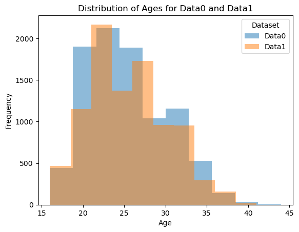

```python
# Write your own code

plt.hist(data0['Age'], alpha=0.5, label='Data0')
plt.hist(data1['Age'], alpha=0.5, label='Data1')
plt.xlabel('Age')
plt.ylabel('Frequency')
plt.title('Distribution of Ages for Data0 and Data1')
plt.legend(title = 'Dataset')
plt.show()
```